# Airbnb Listing Market Analysis

1. Business problem and project objective Business problem

Airbnb hosts and market researchers need to understand how listing prices vary across room types and neighbourhoods, and whether listing characteristics such as availability, reviews, and accommodation capacity are associated with pricing.

Without this analysis, hosts may struggle to compare their listing with similar properties, identify areas with different price levels, or understand which listing attributes are worth investigating further.

# Project objective

- Explore Airbnb listing data and assess its quality.
- Compare prices across room types and neighbourhood groups.
- Investigate relationships between price, reviews, availability, and accommodation features.
- Identify patterns that could help hosts make more informed pricing and listing decisions.

```python
# 1. Import important libraries which we are going to use

import numpy as np
import seaborn as sns
import matplotlib.pyplot as plt
import pandas as pd
```

```python
# 2. Read CSV File

df=pd.read_csv(r'C:\Akshay\Data Analytics\Projects\Python EDA\NYC Airbnb\datasets.csv')
df.head(10)
```

|  | id | name | host_id | host_name | neighbourhood_group | neighbourhood | latitude | longitude | room_type | price | ... | last_review | reviews_per_month | calculated_host_listings_count | availability_365 | number_of_reviews_ltm | license | rating | bedrooms | beds | baths |
| --- | --- | --- | --- | --- | --- | --- | --- | --- | --- | --- | --- | --- | --- | --- | --- | --- | --- | --- | --- | --- | --- |
| 0 | 1.312228e+06 | Rental unit in Brooklyn · ★5.0 · 1 bedroom | 7130382 | Walter | Brooklyn | Clinton Hill | 40.683710 | -73.964610 | Private room | 55.0 | ... | 20/12/15 | 0.03 | 1.0 | 0.0 | 0.0 | No License | 5 | 1 | 1 | Not specified |
| 1 | 4.527754e+07 | Rental unit in New York · ★4.67 · 2 bedrooms ·... | 51501835 | Jeniffer | Manhattan | Hell's Kitchen | 40.766610 | -73.988100 | Entire home/apt | 144.0 | ... | 01/05/23 | 0.24 | 139.0 | 364.0 | 2.0 | No License | 4.67 | 2 | 1 | 1 |
| 2 | 9.710000e+17 | Rental unit in New York · ★4.17 · 1 bedroom · ... | 528871354 | Joshua | Manhattan | Chelsea | 40.750764 | -73.994605 | Entire home/apt | 187.0 | ... | 18/12/23 | 1.67 | 1.0 | 343.0 | 6.0 | Exempt | 4.17 | 1 | 2 | 1 |
| 3 | 3.857863e+06 | Rental unit in New York · ★4.64 · 1 bedroom · ... | 19902271 | John And Catherine | Manhattan | Washington Heights | 40.835600 | -73.942500 | Private room | 120.0 | ... | 17/09/23 | 1.38 | 2.0 | 363.0 | 12.0 | No License | 4.64 | 1 | 1 | 1 |
| 4 | 4.089661e+07 | Condo in New York · ★4.91 · Studio · 1 bed · 1... | 61391963 | Stay With Vibe | Manhattan | Murray Hill | 40.751120 | -73.978600 | Entire home/apt | 85.0 | ... | 03/12/23 | 0.24 | 133.0 | 335.0 | 3.0 | No License | 4.91 | Studio | 1 | 1 |
| 5 | 4.958498e+07 | Rental unit in New York · ★5.0 · 1 bedroom · 1... | 51501835 | Jeniffer | Manhattan | Hell's Kitchen | 40.759950 | -73.992960 | Entire home/apt | 115.0 | ... | 29/07/23 | 0.16 | 139.0 | 276.0 | 2.0 | No License | 5 | 1 | 1 | 1 |
| 6 | 4.527754e+07 | Rental unit in New York · ★4.67 · 2 bedrooms ·... | 51501835 | Jeniffer | Manhattan | Hell's Kitchen | 40.766610 | -73.988100 | Entire home/apt | 144.0 | ... | 01/05/23 | 0.24 | 139.0 | 364.0 | 2.0 | No License | 4.67 | 2 | 1 | 1 |
| 7 | 9.710000e+17 | Rental unit in New York · ★4.17 · 1 bedroom · ... | 528871354 | Joshua | Manhattan | Chelsea | 40.750764 | -73.994605 | Entire home/apt | 187.0 | ... | 18/12/23 | 1.67 | 1.0 | 343.0 | 6.0 | Exempt | 4.17 | 1 | 2 | 1 |
| 8 | 3.857863e+06 | Rental unit in New York · ★4.64 · 1 bedroom · ... | 19902271 | John And Catherine | Manhattan | Washington Heights | 40.835600 | -73.942500 | Private room | 120.0 | ... | 17/09/23 | 1.38 | 2.0 | 363.0 | 12.0 | No License | 4.64 | 1 | 1 | 1 |
| 9 | 4.089661e+07 | Condo in New York · ★4.91 · Studio · 1 bed · 1... | 61391963 | Stay With Vibe | Manhattan | Murray Hill | 40.751120 | -73.978600 | Entire home/apt | 85.0 | ... | 03/12/23 | 0.24 | 133.0 | 335.0 | 3.0 | No License | 4.91 | Studio | 1 | 1 |

10 rows × 22 columns

```python
# 3. DATA INSPECTION

# 1. Dataset size
print("Rows:", df.shape[0])
print("Columns:", df.shape[1])

# 2. Missing values
missing_summary = pd.DataFrame({
    "Missing_Count": df.isnull().sum(),
    "Missing_Percentage": df.isnull().mean() * 100
}).sort_values("Missing_Percentage", ascending=False)

display(missing_summary)

# 3. Duplicate checks
print("Duplicate rows:", df.duplicated().sum())

if "id" in df.columns:
    print("Duplicate listing IDs:", df["id"].duplicated().sum())

# 4. Numeric validation
for col in ["price", "minimum_nights",
             "availability_365", "number_of_reviews"]:
    if col in df.columns:
        print(f"\n{col}")
        print("Negative values:", (df[col] < 0).sum())
```

```
Rows: 20770
Columns: 22
```

|  | Missing_Count | Missing_Percentage |
| --- | --- | --- |
| price | 34 | 0.163698 |
| neighbourhood | 7 | 0.033702 |
| room_type | 7 | 0.033702 |
| longitude | 7 | 0.033702 |
| latitude | 7 | 0.033702 |
| minimum_nights | 7 | 0.033702 |
| calculated_host_listings_count | 7 | 0.033702 |
| availability_365 | 7 | 0.033702 |
| number_of_reviews_ltm | 7 | 0.033702 |
| reviews_per_month | 7 | 0.033702 |
| last_review | 7 | 0.033702 |
| number_of_reviews | 7 | 0.033702 |
| id | 0 | 0.000000 |
| name | 0 | 0.000000 |
| neighbourhood_group | 0 | 0.000000 |
| host_name | 0 | 0.000000 |
| host_id | 0 | 0.000000 |
| license | 0 | 0.000000 |
| rating | 0 | 0.000000 |
| bedrooms | 0 | 0.000000 |
| beds | 0 | 0.000000 |
| baths | 0 | 0.000000 |

```
Duplicate rows: 12
Duplicate listing IDs: 7567

price
Negative values: 0

minimum_nights
Negative values: 0

availability_365
Negative values: 0

number_of_reviews
Negative values: 0
```

# Data Cleaning

```python
# 4. Drop duplicates and null values

df.isnull().sum()
df.dropna(inplace=True)
df.info()
df.duplicated().sum()
df.drop_duplicates(inplace=True)
df.duplicated().sum()
```

```
<class 'pandas.DataFrame'>
Index: 20736 entries, 0 to 20769
Data columns (total 22 columns):
 #   Column                          Non-Null Count  Dtype
---  ------                          --------------  -----
 0   id                              20736 non-null  float64
 1   name                            20736 non-null  str
 2   host_id                         20736 non-null  int64
 3   host_name                       20736 non-null  str
 4   neighbourhood_group             20736 non-null  str
 5   neighbourhood                   20736 non-null  str
 6   latitude                        20736 non-null  float64
 7   longitude                       20736 non-null  float64
 8   room_type                       20736 non-null  str
 9   price                           20736 non-null  float64
 10  minimum_nights                  20736 non-null  float64
 11  number_of_reviews               20736 non-null  float64
 12  last_review                     20736 non-null  str
 13  reviews_per_month               20736 non-null  float64
 14  calculated_host_listings_count  20736 non-null  float64
 15  availability_365                20736 non-null  float64
 16  number_of_reviews_ltm           20736 non-null  float64
 17  license                         20736 non-null  str
 18  rating                          20736 non-null  str
 19  bedrooms                        20736 non-null  str
 20  beds                            20736 non-null  int64
 21  baths                           20736 non-null  str
dtypes: float64(10), int64(2), str(10)
memory usage: 3.6 MB
```

```
np.int64(0)
```

```python
# 5. Change Data Types (Type casting)

df['id']=df['id'].astype('object')
df['host_id']=df['host_id'].astype('object')
df['name']=df['name'].astype('object')
df['host_name']=df['host_name'].astype('object')
df['neighbourhood_group']=df['neighbourhood_group'].astype('object')
df['neighbourhood']=df['neighbourhood'].astype('object')
df['room_type']=df['room_type'].astype('object')
df['last_review']=df['last_review'].astype('object')
df['license']=df['license'].astype('object')
df['rating']=df['rating'].astype('object')
df['bedrooms']=df['bedrooms'].astype('object')
df['baths']=df['baths'].astype('object')
df.dtypes
```

```
id                                 object
name                               object
host_id                            object
host_name                          object
neighbourhood_group                object
neighbourhood                      object
latitude                          float64
longitude                         float64
room_type                          object
price                             float64
minimum_nights                    float64
number_of_reviews                 float64
last_review                        object
reviews_per_month                 float64
calculated_host_listings_count    float64
availability_365                  float64
number_of_reviews_ltm             float64
license                            object
rating                             object
bedrooms                           object
beds                                int64
baths                              object
dtype: object
```

# Univariate Analysis

```python
df.describe()
```

|  | latitude | longitude | price | minimum_nights | number_of_reviews | reviews_per_month | calculated_host_listings_count | availability_365 | number_of_reviews_ltm | beds |
| --- | --- | --- | --- | --- | --- | --- | --- | --- | --- | --- |
| count | 20724.000000 | 20724.000000 | 20724.000000 | 20724.000000 | 20724.000000 | 20724.000000 | 20724.000000 | 20724.000000 | 20724.000000 | 20724.000000 |
| mean | 40.726843 | -73.939155 | 187.732195 | 28.566396 | 42.592646 | 1.257529 | 18.840041 | 205.940938 | 10.844480 | 1.723412 |
| std | 0.060320 | 0.061442 | 1023.539393 | 33.560272 | 73.534712 | 1.905221 | 70.944874 | 135.101383 | 21.359681 | 1.211237 |
| min | 40.500314 | -74.249840 | 10.000000 | 1.000000 | 1.000000 | 0.010000 | 1.000000 | 0.000000 | 0.000000 | 1.000000 |
| 25% | 40.684150 | -73.980760 | 80.000000 | 30.000000 | 4.000000 | 0.210000 | 1.000000 | 87.000000 | 1.000000 | 1.000000 |
| 50% | 40.722937 | -73.949599 | 125.000000 | 30.000000 | 14.000000 | 0.650000 | 2.000000 | 214.000000 | 3.000000 | 1.000000 |
| 75% | 40.763132 | -73.917430 | 199.000000 | 30.000000 | 49.000000 | 1.800000 | 5.000000 | 353.000000 | 15.000000 | 2.000000 |
| max | 40.911147 | -73.713650 | 100000.000000 | 1250.000000 | 1865.000000 | 75.490000 | 713.000000 | 365.000000 | 1075.000000 | 42.000000 |

```python
price_summary = df.groupby("room_type")["price"].agg(
    Listing_Count="count",
    Median_Price="median",
    Mean_Price="mean",
    Min_Price="min",
    Max_Price="max"
)

display(price_summary.sort_values("Median_Price"))

# Percentiles
percentiles = df["price"].quantile(
    [0.25, 0.50, 0.75, 0.90, 0.95]
)

display(percentiles)
```

| room_type | Listing_Count | Median_Price | Mean_Price | Min_Price | Max_Price |
| --- | --- | --- | --- | --- | --- |
| Shared room | 291 | 77.0 | 156.680412 | 14.0 | 10000.0 |
| Private room | 8791 | 80.0 | 139.574792 | 10.0 | 100000.0 |
| Entire home/apt | 11530 | 160.0 | 223.025152 | 10.0 | 10000.0 |
| Hotel room | 112 | 222.0 | 415.053571 | 80.0 | 7590.0 |

```
0.25     80.00
0.50    125.00
0.75    199.00
0.90    309.00
0.95    429.85
Name: price, dtype: float64
```

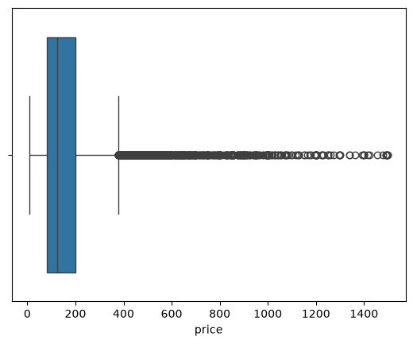

```python
# Identyfying Outliers in price
data= df[df['price']<1500]
sns.boxplot(x='price', data=data)
```

[output not shown]

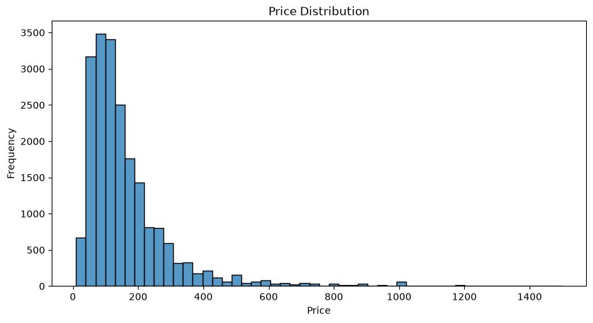

```python
plt.figure(figsize=(10,5))
sns.histplot(data=data, x='price', bins=50)
plt.title('Price Distribution')
plt.xlabel('Price')
plt.ylabel('Frequency')
plt.show
```

Outcome : The price distribution is right-skewed: the median listing price is 125, while the 95th percentile is 429.85. This indicates that a relatively small portion of listings are priced substantially higher than the typical listing.

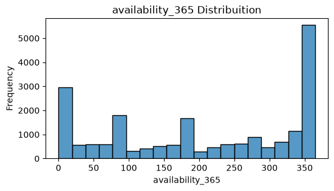

```python
plt.figure(figsize=(6, 3))
sns.histplot(data=df, x='availability_365')
plt.title('availability_365 Distribuition')
plt.ylabel("Frequency")
plt.show()
```

```python
df.dtypes
```

```
id                                 object
name                               object
host_id                            object
host_name                          object
neighbourhood_group                object
neighbourhood                      object
latitude                          float64
longitude                         float64
room_type                          object
price                             float64
minimum_nights                    float64
number_of_reviews                 float64
last_review                        object
reviews_per_month                 float64
calculated_host_listings_count    float64
availability_365                  float64
number_of_reviews_ltm             float64
license                            object
rating                             object
bedrooms                           object
beds                                int64
baths                              object
dtype: object
```

```python
# price per neighbourhood group
df.groupby(by='neighbourhood_group')['price'].mean()
```

```
neighbourhood_group
Bronx            118.407798
Brooklyn         187.196647
Manhattan        227.482034
Queens           126.521415
Staten Island    118.780069
Name: price, dtype: float64
```

```python
# price per bed
df['price per bed']= df['price']/df['beds']
df.groupby(by='neighbourhood_group')['price per bed'].mean()
```

```
neighbourhood_group
Bronx             85.165996
Brooklyn         128.361667
Manhattan        151.931643
Queens            78.507630
Staten Island     67.728101
Name: price per bed, dtype: float64
```

Manhattan has the highest mean price per bed at approximately 151.93, followed by Brooklyn at 128.36. Staten Island has the lowest mean price per bed at approximately 67.73.

This provides a capacity-adjusted comparison of listing prices across neighbourhood groups.

```python
df["availability_segment"] = pd.cut(
    df["availability_365"],
    bins=[-1, 90, 180, 270, 365],
    labels=[
        "Low",
        "Moderate",
        "High",
        "Very High"
    ]
)

availability_analysis = df.groupby(
    "availability_segment",
    observed=True
).agg(
    Listing_Count=("id", "nunique"),
    Median_Price=("price", "median"),
    Median_Reviews=("number_of_reviews", "median"),
    Median_Availability=("availability_365", "median")
)

display(availability_analysis)
```

| availability_segment | Listing_Count | Median_Price | Median_Reviews | Median_Availability |
| --- | --- | --- | --- | --- |
| Low | 4813 | 120.0 | 16.0 | 27.0 |
| Moderate | 2569 | 125.0 | 22.0 | 161.0 |
| High | 1755 | 131.0 | 12.0 | 242.0 |
| Very High | 5300 | 126.0 | 12.0 | 363.0 |

# Bivariate Analysis

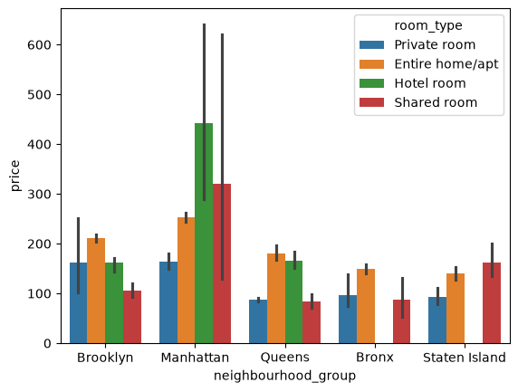

```python
sns.barplot(data=df, x='neighbourhood_group', y='price', hue='room_type')
```

Entire homes/apartments have a median price of 160, twice the median price of private rooms at 80. Hotel rooms have the highest median and mean prices in this dataset, although the hotel-room category has only 112 listings.

The hotel-room mean price of 415.05 is considerably higher than its median of 222, suggesting that high-priced hotel listings influence the average.

Manhattan has the highest mean listing price at approximately 227.48, followed by Brooklyn at 187.20. Bronx and Staten Island have the lowest mean prices, both close to 119.

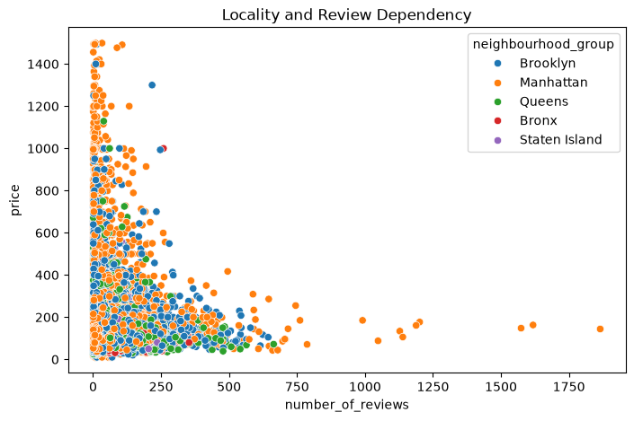

```python
# number of reviews and price relation based on locations
plt.figure(figsize=(8, 5))
plt.title("Locality and Review Dependency")
sns.scatterplot(data=data, x='number_of_reviews', y='price', hue='neighbourhood_group')
plt.show()
```

```python
df.dtypes
```

```
id                                 object
name                               object
host_id                            object
host_name                          object
neighbourhood_group                object
neighbourhood                      object
latitude                          float64
longitude                         float64
room_type                          object
price                             float64
minimum_nights                    float64
number_of_reviews                 float64
last_review                        object
reviews_per_month                 float64
calculated_host_listings_count    float64
availability_365                  float64
number_of_reviews_ltm             float64
license                            object
rating                             object
bedrooms                           object
beds                                int64
baths                              object
price per bed                     float64
dtype: object
```

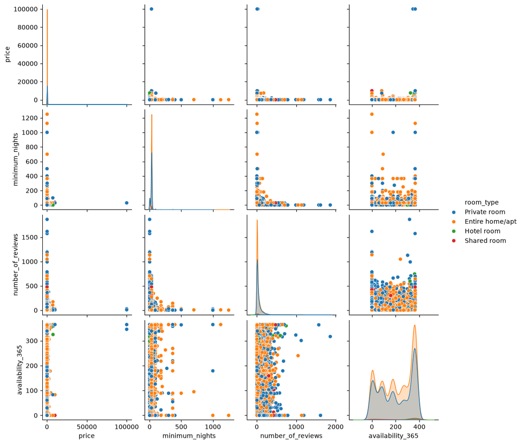

```python
sns.pairplot(data=df,vars=['price','minimum_nights','number_of_reviews','availability_365'], hue='room_type')
#sns.pairplot(data=df, vars=['price', 'minimum_nights', 'number_of_reviews', 'availability_365'], hue='room_type')
```

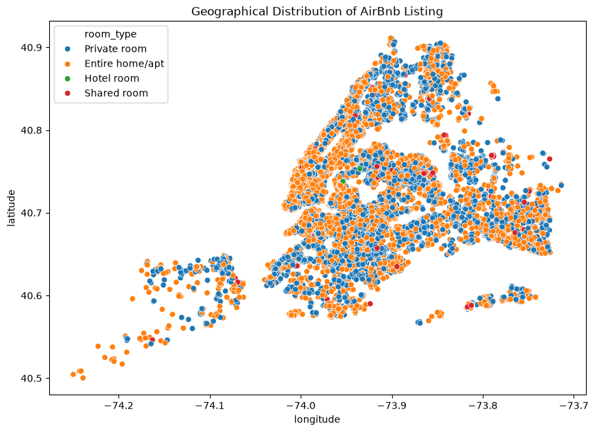

```python
#Geographical Distribution of AirBnb Listing
plt.figure(figsize=(10, 7))
sns.scatterplot(data=df, x='longitude', y='latitude', hue='room_type')
plt.title("Geographical Distribution of AirBnb Listing")
plt.show()
```

The chart visualises the geographical spread of Airbnb listings and allows the reader to explore whether room types appear clustered in particular locations.

# Multivariate Analysis

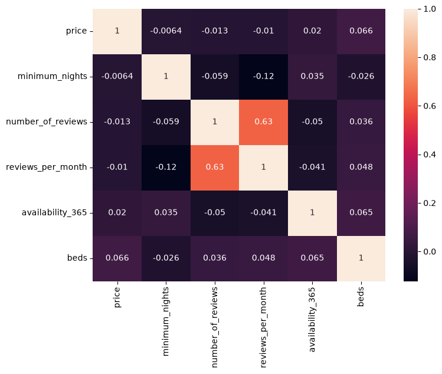

```python
corr = df[['price', 'minimum_nights', 'number_of_reviews', 'reviews_per_month', 'availability_365', 'beds']].corr()
corr
plt.figure(figsize=(8, 6))
sns.heatmap(data=corr, annot=True)
```

# Overall Conclusion

Overall Conclusion

This exploratory data analysis examined Airbnb listing data to understand how listing prices vary across room types and neighbourhood groups, and how pricing relates to listing characteristics such as availability, reviews, and accommodation capacity.

The analysis identified several important patterns:

1. Accommodation type: Entire homes/apartments have a median listing price of 160, compared with 80 for private rooms. Hotel rooms have the highest median and mean prices among the room types in the dataset, although the hotel-room category contains fewer listings.
2. Geographical pricing: Manhattan has the highest average listing price at approximately 227.48, followed by Brooklyn at 187.20. Bronx and Staten Island have lower average listing prices.
3. Price distribution: The listing-price distribution is right-skewed, with a median of 125 and a 95th-percentile price of 429.85. This highlights the importance of examining outliers and using median prices alongside averages.
4. Price relative to accommodation capacity: Manhattan has the highest mean price per bed at approximately 151.93, while Staten Island has the lowest at approximately 67.73.

Overall, the findings indicate that room type and geographical location are important dimensions for comparing Airbnb listing prices. The analysis provides a foundation for more detailed pricing research and for helping hosts benchmark their listings against similar properties.